# examenEstadistica2023

Se realiza validacion de la instalación de los paquetes necesarios para ejecutar el script

```r
rm(list = ls())

# Bibliotecas a cargar


check_packages <- function(packages) {
  if (all(packages %in% rownames(installed.packages()))) {
    TRUE
  } else{
    cat(
      "Instalar los siguientes packages antes de ejecutar el presente script\n",
      packages[!(packages %in% rownames(installed.packages()))],
      "\n"
    )
  }
}
packages_needed <- c("repmis")

# Se llama a la funcion check_packages
check_packages(packages_needed)
```

```
## [1] TRUE
```

```r
library(repmis)
```

# Ejercicio N° 1 - Estadística Descriptiva (15 puntos)

Seleccione una base de datos pública de su interés y seleccione una muestra de n observaciones aleatorias al azar. Alternativamente, simule una muestra aleatoria simple de al menos 1000 registros. Para la entrega de este examen deberá adjuntar la muestra seleccionada y el procedimiento que permitir obtener los registros muestrales. A partir de la misma se solicita lo siguiente,

Base de datos públicas a utilizar en el ejercicio:

```r
##Se comparte URL del archivo trabajado
URLEjer1<-"https://d3c33hcgiwev3.cloudfront.net/1sf2mERLTmuH9phES65rBw_a8f877dcd6d84ca3b48e8390d40c74f1_Ordenes_productos_C1_M2.csv?Expires=1675641600&Signature=iVg7NljP9Bz3iZmt3LKXouVnrPxlN5TmuSB7ccYcV~cyUHVjqTX5zp-qVG8J7XSd6Td9ID5gzkC~eYn-PxAmVNgOj6QfdFNdcfy3WYQ~ISMgg6dfp2N~Y48dDpoglh5PuBeWCKA1dBRES3F3H2dHD-FntYvYic9L9-D84grVR-0_&Key-Pair-Id=APKAJLTNE6QMUY6HBC5A"
#url_archivo <- paste(URLEjer1,"Ordenes_productos_C1_M2.csv", sep = ";")


#Se carga el archivo de forma local, esto por no saber como cargado desde la web.
file<-"C:/Users/Josvaldes/Documents/Maestria/Austral/1 ano/Estadistica/examen/Ordenes_productos_C1_M2.csv"
ordenesProductosRetiel <- read.csv(file, sep = ";", header = TRUE)
```

Se procede con la selección de una muestra aleatoria al azar, prueba con 1000 registros:

```r
#se transforma la lista contenida en el objeto ordenesProductosRetiel en un data frame

df<-data.frame(matrix(unlist(ordenesProductosRetiel), nrow = length(ordenesProductosRetiel), byrow = TRUE))


#se selecciona una muestra aleatoria simple del data frame
muestra1000registros <- df[sample(nrow(df), size=1000, replace = TRUE, prob = NULL)]

#Se cambia los nombres de las variables a trabajar
value <- c("orden_id","order_item_id","producto_id","vendedor_id","fecha_envio_limite","precio","valor_flete","codigo_postal_vendedor","ciudad_vendedor","departamento_vendedor","nombre_categoria_producto","longitud_nombre_producto","longitud_descripcion_producto","cantidad_fotos_producto","peso_g_producto","longitud_cm_producto","altura_cm_producto","ancho_cm_producto")

row.names(muestra1000registros) <- value

#Se usa la función de transpuesta para regresar las filas y las columnas a la estructura original y dejar el objeto como un data frame
df00<-as.data.frame(t(muestra1000registros))
```

Debido a que las conversiones ocasionaron que el tipo de datos cambiara todo a carácter se hace la corrección de las columnas al tipo de dato del dataset original:

```r
df00$precio=as.numeric(df00$precio)
df00$valor_flete=as.numeric(df00$valor_flete)
df00$codigo_postal_vendedor=as.integer(df00$codigo_postal_vendedor)
df00$longitud_nombre_producto=as.integer(df00$longitud_nombre_producto)
df00$longitud_descripcion_producto=as.integer(df00$longitud_descripcion_producto)
df00$cantidad_fotos_producto=as.integer(df00$cantidad_fotos_producto)
df00$peso_g_producto=as.integer(df00$peso_g_producto)
df00$longitud_cm_producto=as.integer(df00$longitud_cm_producto)
df00$altura_cm_producto=as.integer(df00$altura_cm_producto)
df00$ancho_cm_producto=as.integer(df00$ancho_cm_producto)
str(df00)
```

```
## 'data.frame':    1000 obs. of  18 variables:
##  $ orden_id                     : chr  "107500PO59A" "12622PN88A" "11139PA88A" "23409PQ21A" ...
##  $ order_item_id                : chr  "A" "A" "A" "A" ...
##  $ producto_id                  : chr  "PO59" "PN88" "PA88" "PQ21" ...
##  $ vendedor_id                  : chr  "VE5389" "VE9449" "VE7147" "VE2821" ...
##  $ fecha_envio_limite           : chr  "7/04/2018 18:12" "29/09/2017 14:01" "4/05/2018 12:19" "11/12/2017 22:48" ...
##  $ precio                       : num  271.9 336.4 50.1 51.6 61 ...
##  $ valor_flete                  : num  30.72 12.5 0.32 3.47 52.69 ...
##  $ codigo_postal_vendedor       : int  52435 70001 70001 8001 81001 52435 81001 54003 81001 70001 ...
##  $ ciudad_vendedor              : chr  "Mallama" "Sincelejo" "Sincelejo" "Barranquilla" ...
##  $ departamento_vendedor        : chr  "Nari\xf1o" "Sucre" "Sucre" "Atlantico" ...
##  $ nombre_categoria_producto    : chr  "Productos ecoamigables" "" "" "" ...
##  $ longitud_nombre_producto     : int  6 NA NA NA 21 10 21 NA 21 NA ...
##  $ longitud_descripcion_producto: int  7 NA NA NA 33 1 33 NA 33 NA ...
##  $ cantidad_fotos_producto      : int  27 NA NA NA 0 6 0 NA 0 NA ...
##  $ peso_g_producto              : int  2486 NA NA NA 258 734 258 NA 258 NA ...
##  $ longitud_cm_producto         : int  17 NA NA NA 22 46 22 NA 22 NA ...
##  $ altura_cm_producto           : int  11 NA NA NA 24 48 24 NA 24 NA ...
##  $ ancho_cm_producto            : int  14 NA NA NA 25 22 25 NA 25 NA ...
```

Sobre el objeto ordenesProductosRetiel se entrega el dataset utilizado para el ejercicio y sobre el objeto df00 se entrega la muestra aleatoria simple de 1000 observaciones del dataset.

• Describir para este caso la población, la muestra tomada, el experimento que estará usando, las variables bajo análisis y cualquier otra característica relevante para el procedimiento. Si la base es simulada, exponga los motivos por los cuales el procedimiento es viable.

```r
#La población utilizada es la que esta en el dataset ordenesProductosRetiel las caracteristicas del objeto son las siguiente: 10134 obs. of  18 variables:
str(ordenesProductosRetiel)
```

```
## 'data.frame':    10134 obs. of  18 variables:
##  $ orden_id                     : chr  "107500PO59A" "37493PS22B" "28050PK20B" "52187PA10A" ...
##  $ order_item_id                : chr  "A" "B" "B" "A" ...
##  $ producto_id                  : chr  "PO59" "PS22" "PK20" "PA10" ...
##  $ vendedor_id                  : chr  "VE5389" "VE1558" "VE9159" "VE3159" ...
##  $ fecha_envio_limite           : chr  "7/04/2018 18:12" "20/10/2017 9:07" "17/08/2017 8:15" "23/09/2017 23:27" ...
##  $ precio                       : num  271.9 115.7 433 108.4 51.5 ...
##  $ valor_flete                  : num  30.72 4.68 82.7 35.39 11.1 ...
##  $ codigo_postal_vendedor       : int  52435 52203 66001 52435 73001 52356 52240 50683 52381 66001 ...
##  $ ciudad_vendedor              : chr  "Mallama" "Colon" "Pereira" "Mallama" ...
##  $ departamento_vendedor        : chr  "Nari\xf1o" "Nari\xf1o" "Risaralda" "Nari\xf1o" ...
##  $ nombre_categoria_producto    : chr  "Productos ecoamigables" "Carnicer\xeda" "Deportes" "Electrodom\xe9sticos" ...
##  $ longitud_nombre_producto     : int  6 10 25 10 23 13 8 5 7 1 ...
##  $ longitud_descripcion_producto: int  7 31 5 1 16 19 37 35 11 39 ...
##  $ cantidad_fotos_producto      : int  27 20 4 6 35 29 24 26 30 33 ...
##  $ peso_g_producto              : int  2486 256 5270 734 884 811 621 286 30 16 ...
##  $ longitud_cm_producto         : int  17 43 9 46 45 29 26 29 50 11 ...
##  $ altura_cm_producto           : int  11 2 27 48 26 9 41 21 26 42 ...
##  $ ancho_cm_producto            : int  14 21 29 22 18 16 29 18 17 12 ...
```

```r
#La muestra utilizada es la que esta en el objeto df00 las caracteristicas del objeto son las siguiente: 1000 obs. of  18 variables:
str(df00)
```

```
## 'data.frame':    1000 obs. of  18 variables:
##  $ orden_id                     : chr  "107500PO59A" "12622PN88A" "11139PA88A" "23409PQ21A" ...
##  $ order_item_id                : chr  "A" "A" "A" "A" ...
##  $ producto_id                  : chr  "PO59" "PN88" "PA88" "PQ21" ...
##  $ vendedor_id                  : chr  "VE5389" "VE9449" "VE7147" "VE2821" ...
##  $ fecha_envio_limite           : chr  "7/04/2018 18:12" "29/09/2017 14:01" "4/05/2018 12:19" "11/12/2017 22:48" ...
##  $ precio                       : num  271.9 336.4 50.1 51.6 61 ...
##  $ valor_flete                  : num  30.72 12.5 0.32 3.47 52.69 ...
##  $ codigo_postal_vendedor       : int  52435 70001 70001 8001 81001 52435 81001 54003 81001 70001 ...
##  $ ciudad_vendedor              : chr  "Mallama" "Sincelejo" "Sincelejo" "Barranquilla" ...
##  $ departamento_vendedor        : chr  "Nari\xf1o" "Sucre" "Sucre" "Atlantico" ...
##  $ nombre_categoria_producto    : chr  "Productos ecoamigables" "" "" "" ...
##  $ longitud_nombre_producto     : int  6 NA NA NA 21 10 21 NA 21 NA ...
##  $ longitud_descripcion_producto: int  7 NA NA NA 33 1 33 NA 33 NA ...
##  $ cantidad_fotos_producto      : int  27 NA NA NA 0 6 0 NA 0 NA ...
##  $ peso_g_producto              : int  2486 NA NA NA 258 734 258 NA 258 NA ...
##  $ longitud_cm_producto         : int  17 NA NA NA 22 46 22 NA 22 NA ...
##  $ altura_cm_producto           : int  11 NA NA NA 24 48 24 NA 24 NA ...
##  $ ancho_cm_producto            : int  14 NA NA NA 25 22 25 NA 25 NA ...
```

```r
#El experimento que se usa es un muestreo aleatorio simple
#las variables bajo análisis se describen en las salidas de la funcion str()
```

Como se obsservan en las salidas del dataset utilizado relacionado al sector retail, se tiene una base de 10134 observaciones y 18 variables, de esta población se realiza un muestreo aleatorio simple con el cual se toma una muestra aleatoria de 1000 observaciones.

• Generar un set de estadística descriptiva sobre la misma que le permita resumir la información obtenida, explicando para cada una de ellas su significado.

```r
#Se valida el resumen de los datos del data frame (muestra)
summary(df00)
```

```
##    orden_id         order_item_id      producto_id        vendedor_id
##  Length:1000        Length:1000        Length:1000        Length:1000
##  Class :character   Class :character   Class :character   Class :character
##  Mode  :character   Mode  :character   Mode  :character   Mode  :character
##
##
##
##
##  fecha_envio_limite     precio        valor_flete    codigo_postal_vendedor
##  Length:1000        Min.   : 13.48   Min.   : 0.32   Min.   : 8001
##  Class :character   1st Qu.: 51.57   1st Qu.: 4.68   1st Qu.:52240
##  Mode  :character   Median :113.54   Median :12.50   Median :52480
##                     Mean   :156.08   Mean   :24.34   Mean   :56561
##                     3rd Qu.:244.44   3rd Qu.:33.68   3rd Qu.:66001
##                     Max.   :432.99   Max.   :83.65   Max.   :81001
##
##  ciudad_vendedor    departamento_vendedor nombre_categoria_producto
##  Length:1000        Length:1000           Length:1000
##  Class :character   Class :character      Class :character
##  Mode  :character   Mode  :character      Mode  :character
##
##
##
##
##  longitud_nombre_producto longitud_descripcion_producto cantidad_fotos_producto
##  Min.   : 1.00            Min.   : 1.00                 Min.   : 0.0
##  1st Qu.: 6.00            1st Qu.: 7.00                 1st Qu.: 6.0
##  Median :10.00            Median :19.00                 Median :26.0
##  Mean   :11.34            Mean   :21.68                 Mean   :21.2
##  3rd Qu.:21.00            3rd Qu.:35.00                 3rd Qu.:30.0
##  Max.   :25.00            Max.   :39.00                 Max.   :35.0
##  NA's   :374              NA's   :374                   NA's   :374
##  peso_g_producto longitud_cm_producto altura_cm_producto ancho_cm_producto
##  Min.   :  16    Min.   : 9.00        Min.   : 2.00      Min.   :12.0
##  1st Qu.: 256    1st Qu.:17.00        1st Qu.:11.00      1st Qu.:16.0
##  Median : 621    Median :29.00        Median :26.00      Median :18.0
##  Mean   :1011    Mean   :28.86        Mean   :25.32      Mean   :19.8
##  3rd Qu.: 884    3rd Qu.:45.00        3rd Qu.:41.00      3rd Qu.:25.0
##  Max.   :5270    Max.   :50.00        Max.   :48.00      Max.   :29.0
##  NA's   :374     NA's   :374          NA's   :374        NA's   :374
```

Para un análisis más detallado se hace la revisión de cada una de las variables, se excluyen las cualitativas:

Variable Precio

```r
#Población
summary(ordenesProductosRetiel$precio)
```

```
##    Min. 1st Qu.  Median    Mean 3rd Qu.    Max.
##    0.01   34.16   83.12  119.79  165.51 1262.94
```

```r
#muestra
summary(df00$precio)
```

```
##    Min. 1st Qu.  Median    Mean 3rd Qu.    Max.
##   13.48   51.57  113.54  156.08  244.44  432.99
```

Variable valor flete

```r
#Población
summary(ordenesProductosRetiel$valor_flete)
```

```
##    Min. 1st Qu.  Median    Mean 3rd Qu.    Max.
##    0.00    5.76   13.98   20.05   27.45  183.15
```

```r
#muestra
summary(df00$valor_flete)
```

```
##    Min. 1st Qu.  Median    Mean 3rd Qu.    Max.
##    0.32    4.68   12.50   24.34   33.68   83.65
```

longitud_nombre_producto

```r
#Población
summary(ordenesProductosRetiel$longitud_nombre_producto)
```

```
##    Min. 1st Qu.  Median    Mean 3rd Qu.    Max.    NA's
##    0.00   10.00   20.00   20.07   30.00   40.00      23
```

```r
#muestra
summary(df00$longitud_nombre_producto)
```

```
##    Min. 1st Qu.  Median    Mean 3rd Qu.    Max.    NA's
##    1.00    6.00   10.00   11.34   21.00   25.00     374
```

longitud_descripcion_producto

```r
#Población
summary(ordenesProductosRetiel$longitud_descripcion_producto)
```

```
##    Min. 1st Qu.  Median    Mean 3rd Qu.    Max.    NA's
##    0.00   10.00   20.00   19.84   30.00   40.00      23
```

```r
#muestra
summary(df00$longitud_descripcion_producto)
```

```
##    Min. 1st Qu.  Median    Mean 3rd Qu.    Max.    NA's
##    1.00    7.00   19.00   21.68   35.00   39.00     374
```

cantidad_fotos_producto

```r
#Población
summary(ordenesProductosRetiel$cantidad_fotos_producto)
```

```
##    Min. 1st Qu.  Median    Mean 3rd Qu.    Max.    NA's
##     0.0    10.0    20.0    20.1    30.0    40.0      23
```

```r
#muestra
summary(df00$cantidad_fotos_producto)
```

```
##    Min. 1st Qu.  Median    Mean 3rd Qu.    Max.    NA's
##     0.0     6.0    26.0    21.2    30.0    35.0     374
```

altura_cm_producto

```r
#Población
summary(ordenesProductosRetiel$altura_cm_producto)
```

```
##    Min. 1st Qu.  Median    Mean 3rd Qu.    Max.    NA's
##    0.00    9.00   17.00   17.91   26.00   64.00      23
```

```r
#muestra
summary(df00$altura_cm_producto)
```

```
##    Min. 1st Qu.  Median    Mean 3rd Qu.    Max.    NA's
##    2.00   11.00   26.00   25.32   41.00   48.00     374
```

ancho_cm_producto

```r
#Población
summary(ordenesProductosRetiel$ancho_cm_producto)
```

```
##    Min. 1st Qu.  Median    Mean 3rd Qu.    Max.    NA's
##    0.00   15.00   23.00   22.91   30.00   72.00      23
```

```r
#muestra
summary(df00$ancho_cm_producto)
```

```
##    Min. 1st Qu.  Median    Mean 3rd Qu.    Max.    NA's
##    12.0    16.0    18.0    19.8    25.0    29.0     374
```

• Generar un histograma para una de las variables cuantitativas, utilizando la forma que considere más correcta para agrupar las categorías. Elija la variable que mayor simetría consiga en el histograma resultante.

Variable Precio

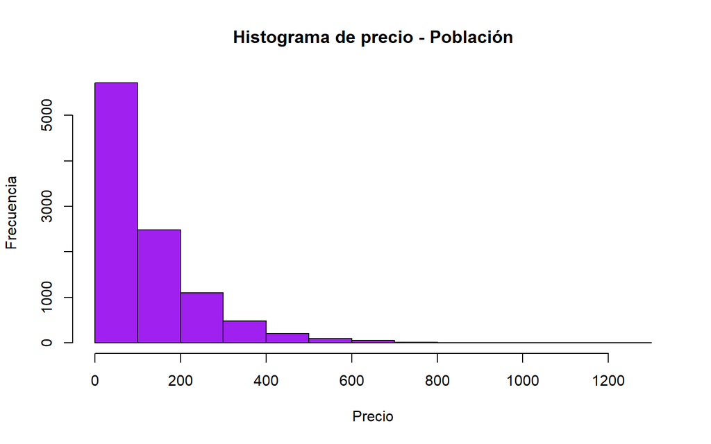

```r
#Histograma población
hist(x = ordenesProductosRetiel$precio, main = "Histograma de precio - Población",
     xlab = "Precio", ylab = "Frecuencia",
     col = "purple")
```

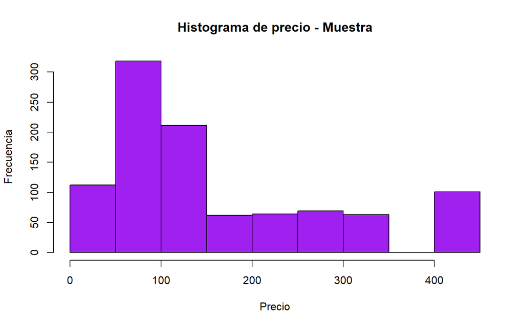

```r
#Histograma muestra
hist(x = df00$precio, main = "Histograma de precio - Muestra",
     xlab = "Precio", ylab = "Frecuencia",
     col = "purple")
```

Variable valor flete

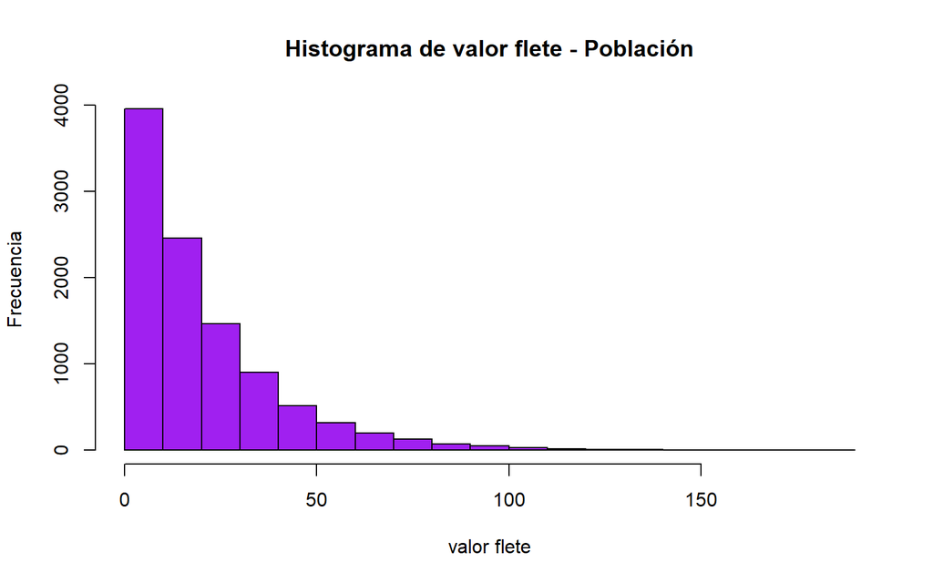

```r
#Histograma población
hist(x = ordenesProductosRetiel$valor_flete, main = "Histograma de valor flete - Población",
     xlab = "valor flete", ylab = "Frecuencia",
     col = "purple")
```

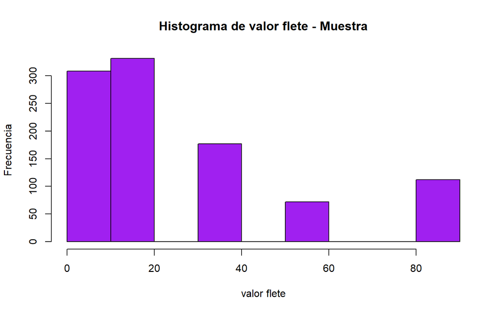

```r
#Histograma muestra
hist(x = df00$valor_flete, main = "Histograma de valor flete - Muestra",
     xlab = "valor flete", ylab = "Frecuencia",
     col = "purple")
```

longitud_nombre_producto

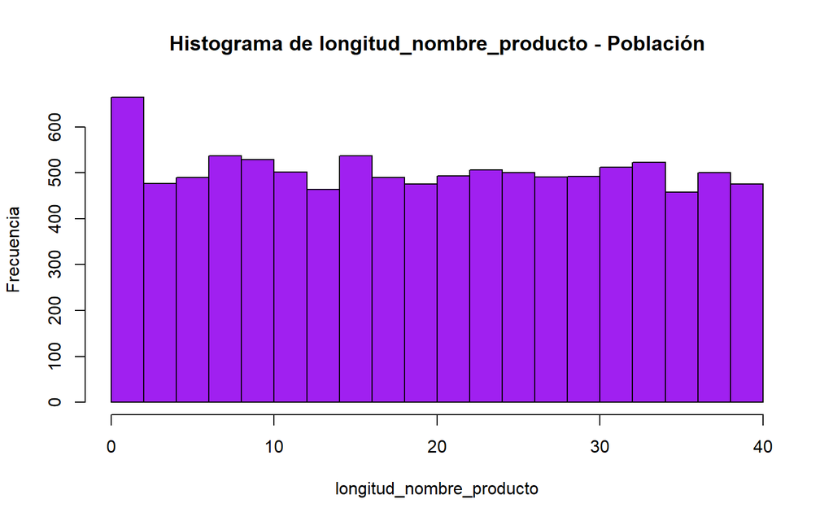

```r
#Histograma población
hist(x = ordenesProductosRetiel$longitud_nombre_producto, main = "Histograma de longitud_nombre_producto - Población",
     xlab = "longitud_nombre_producto", ylab = "Frecuencia",
     col = "purple")
```

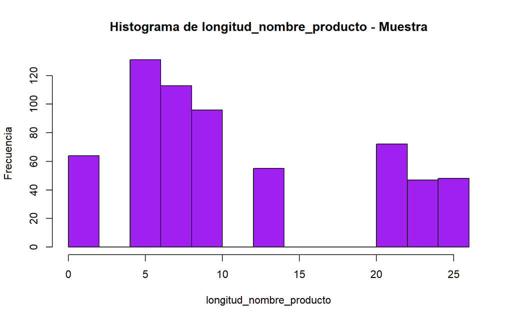

```r
#Histograma muestra
hist(x = df00$longitud_nombre_producto, main = "Histograma de longitud_nombre_producto - Muestra",
     xlab = "longitud_nombre_producto", ylab = "Frecuencia",
     col = "purple")
```

longitud_descripcion_producto

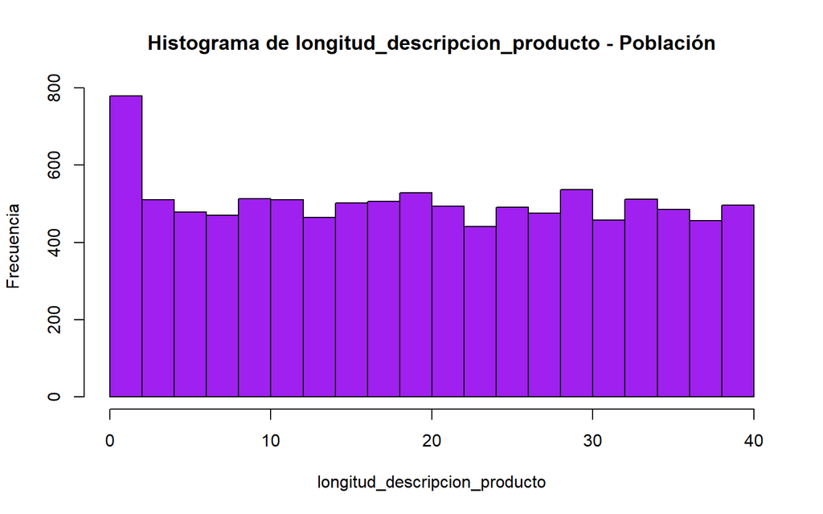

```r
#Histograma población
hist(x = ordenesProductosRetiel$longitud_descripcion_producto, main = "Histograma de longitud_descripcion_producto - Población",
     xlab = "longitud_descripcion_producto", ylab = "Frecuencia",
     col = "purple")
```

[figure not shown]

```r
#Histograma muestra
hist(x = df00$longitud_nombre_producto, main = "Histograma de longitud_descripcion_producto - Muestra",
     xlab = "longitud_descripcion_producto", ylab = "Frecuencia",
     col = "purple")
```

cantidad_fotos_producto

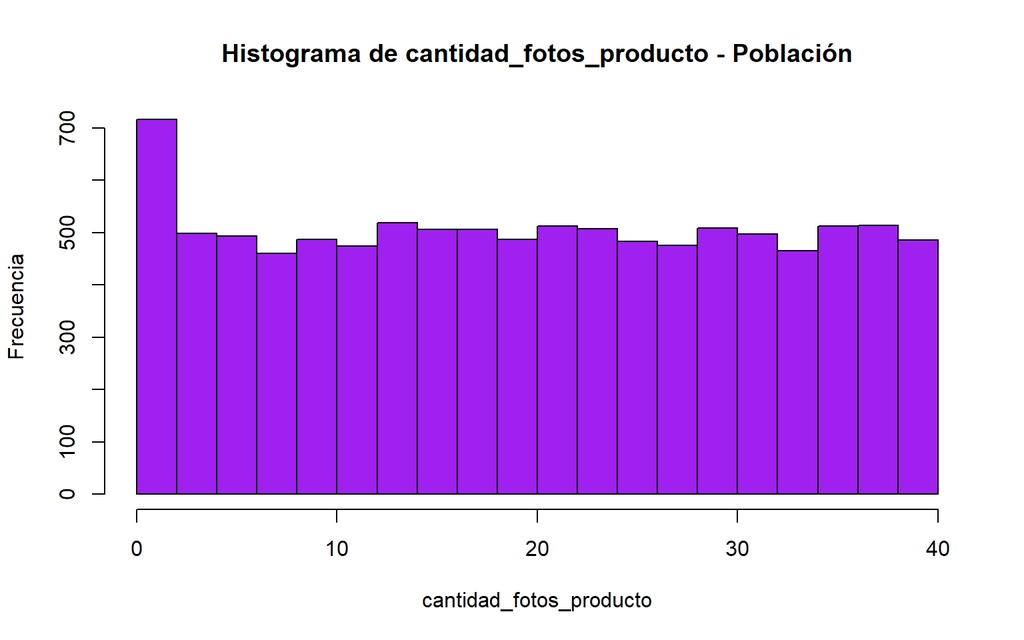

```r
#Histograma población
hist(x = ordenesProductosRetiel$cantidad_fotos_producto, main = "Histograma de cantidad_fotos_producto - Población",
     xlab = "cantidad_fotos_producto", ylab = "Frecuencia",
     col = "purple")
```

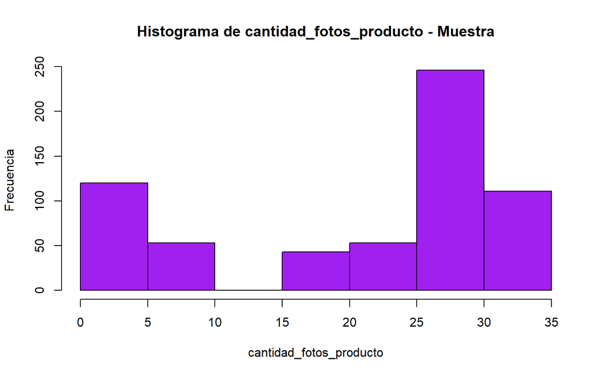

```r
#Histograma muestra
hist(x = df00$cantidad_fotos_producto, main = "Histograma de cantidad_fotos_producto - Muestra",
     xlab = "cantidad_fotos_producto", ylab = "Frecuencia",
     col = "purple")
```

altura_cm_producto

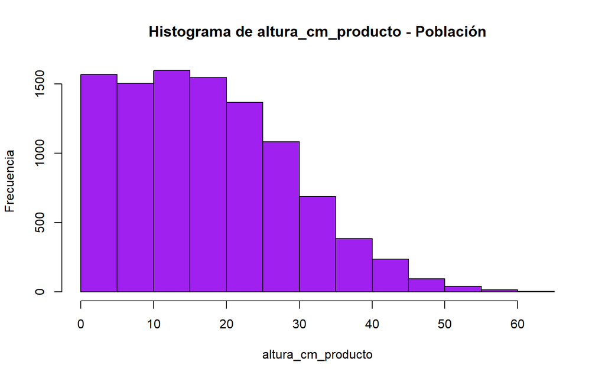

```r
#Histograma población
hist(x = ordenesProductosRetiel$altura_cm_producto, main = "Histograma de altura_cm_producto - Población",
     xlab = "altura_cm_producto", ylab = "Frecuencia",
     col = "purple")
```

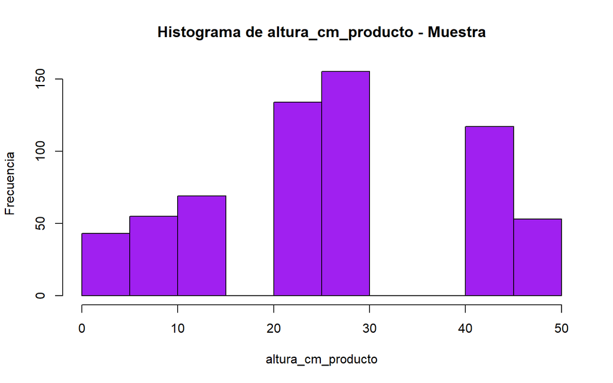

```r
#Histograma muestra
hist(x = df00$altura_cm_producto, main = "Histograma de altura_cm_producto - Muestra",
     xlab = "altura_cm_producto", ylab = "Frecuencia",
     col = "purple")
```

ancho_cm_producto

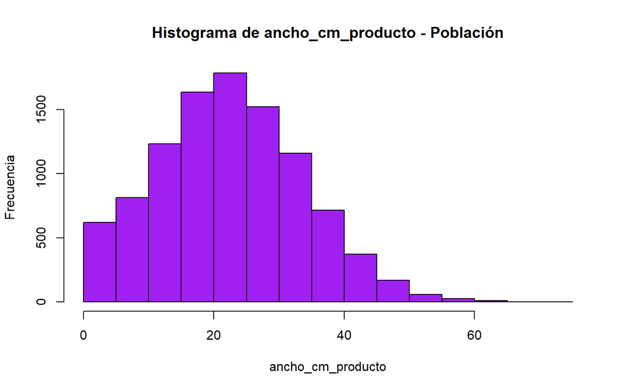

```r
#Histograma población
hist(x = ordenesProductosRetiel$ancho_cm_producto, main = "Histograma de ancho_cm_producto - Población",
     xlab = "ancho_cm_producto", ylab = "Frecuencia",
     col = "purple")
```

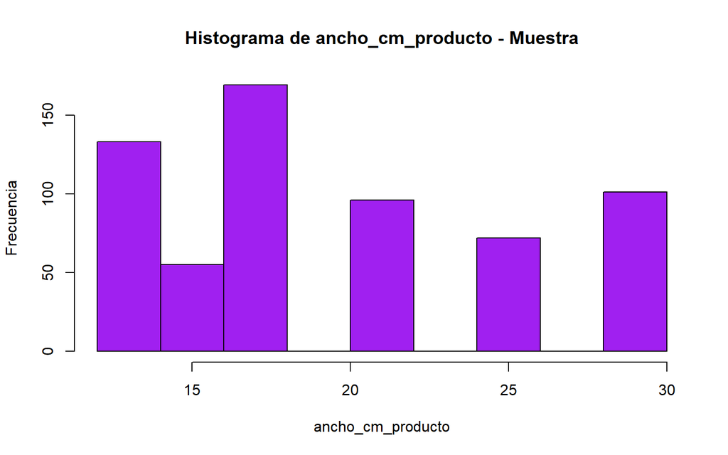

```r
#Histograma muestra
hist(x = df00$ancho_cm_producto, main = "Histograma de ancho_cm_producto - Muestra",
     xlab = "ancho_cm_producto", ylab = "Frecuencia",
     col = "purple")
```

Como se observa en las imágenes anteriores, las variables cuantitativas que presenta mayor simetría son:

• longitud_nombre_producto • longitud_descripcion_producto • cantidad_fotos_producto

Estas variables representan aspectos del producto que no son significativos, para observar características relevantes se toman gráficos en boxplot de las siguientes variables:

• precio • valor flete • altura_cm_producto ancho_cm_producto

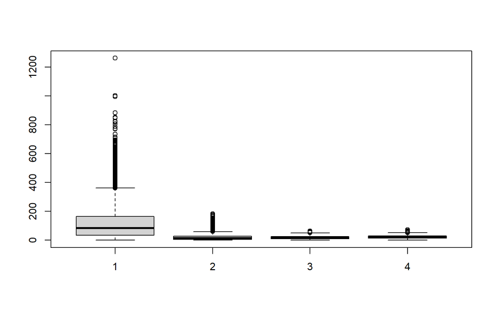

```r
# Boxplot precio, Valor Flete, altura_cm_producto y ancho_cm_producto - Población
boxplot(ordenesProductosRetiel$precio, ordenesProductosRetiel$valor_flete, ordenesProductosRetiel$altura_cm_producto, ordenesProductosRetiel$ancho_cm_producto)
```

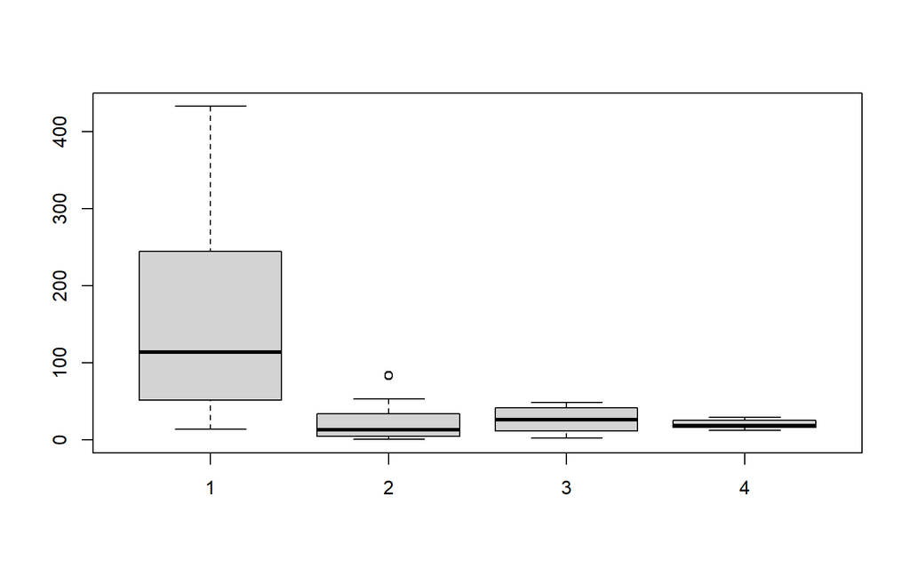

```r
# Boxplot precio, Valor Flete, altura_cm_producto y ancho_cm_producto - muestra
boxplot(df00$precio, df00$valor_flete, df00$altura_cm_producto, df00$ancho_cm_producto)
```

# Ejercicio N° 2 - Probabilidad (15 puntos)

Ejercicio 1 1. Si lanzamos un dado equilibrado de 6 lados, ¿Cuál es la probabilidad esperada de obtener el número 5?. Si lanzamos el dado 10 veces, ¿Cuál es la cantidad esperada de veces que sale dicho número?

R/ La probabilidad de cada una de las caras de un dado equilibrado corresponde a 1/6, esto significa que cada cara tiene la misma probabilidad de presentarse al momento de lanzar el dado, por tal razón, la probabilidad de obtener el numero 5 es del 1/6. Si se lanza el dado equilibrado 10 veces, la probabilidad esperada de obtener el número 5 sería la multiplicación de la cantidad de veces que se lanza el dado por la probabilidad que se obtenga el número deseado: 10 * (1/6) = 1.67 Esto quiere decir que si lanzamos un dado equilibrado 10 veces se tiene la probabilidad de obtener el número 5, una o dos veces de los 10 lanzamientos realizados. Se aclara que el tema de probabilidad se utiliza para predecir resultados a largo plazo, por lo que si realizamos este experimento puede que no se logre la probabilidad estimada, esto por ser un evento con pocas repeticiones, estos eventos son difíciles de predecir y dependen de muchos factores que puedan afectar la prueba ejecutada.

2. Lanzar un dado 10 veces y contar el número de veces que sale 5. Repetirlo 15 veces y almacenar la cantidad de apariciones de dicho número para cada una.

R/ Como se comenta en el punto anterior, estos eventos se pueden calcular con el número de lanzamientos por la probabilidad de obtener cada cara: 10 * (1/6) = 1.67 Almacenar estos resultados y repetirlo 15 veces mas se puede simular en la herramienta R de la siguiente forma:

```r
# para obtener resultados reproducibles, se crea una semilla
set.seed(123)
num_lanzamientos <- 10
num_simulaciones <- 15
resultado <- numeric(num_simulaciones)
for (i in 1:num_simulaciones) {
  dados_Lanzados <- sample(1:6, num_lanzamientos, replace = TRUE)
  resultado[i] <- sum(dados_Lanzados == 5)
  #cat("Simulación ", i, ": ", resultado[i], " veces el número 5.\n")
  #cat("  Datos de los 10 lanzamientos", dados_Lanzados, "\n")
}
```

```r
sum(resultado)
```

```
## [1] 21
```

3. Lanzar el dado 100 veces, contar el número de apariciones de dicho número 5, almacenar el resultado y repetirlo 1000 veces.

R/ Con relación al ejercicio anterior se implementa el mismo código y se retira las salidas de cada simulación para obtener solo el resultado final:

```r
# para obtener resultados reproducibles, se crea una semilla
set.seed(123)
num_lanzamientosEje23 <- 100
num_simulacionesEje23 <- 1000
resultadoEje23 <- numeric(num_simulacionesEje23)
for (i in 1:num_simulacionesEje23) {
  dados_LanzadosEje23 <- sample(1:6, num_lanzamientosEje23, replace = TRUE)
  resultadoEje23[i] <- sum(dados_LanzadosEje23 == 5)
}
sum(resultadoEje23)
```

```
## [1] 16774
```

4. ¿Cómo difieren los resultados del experimento en (2) de los resultados en el experimento (3)? Justificar

R/ Los resultados difieren de las cantidades de repeticiones que se realizan en el punto 2 (10 lanzamientos de un dado equilibrado, conteo de la cantidad de veces que aparece el número 5 y repetido 15 veces) y el punto 3 (100 lanzamientos, conteo del número 5 y repetidos 1000 veces). Estas diferencias afectan la precisión y la fiabilidad de los resultados, entre mas lanzamientos y repeticiones haya mas preciso y confiable será la prueba. En tal sentido, los resultados del punto 3 son mas confiables y precisos por tener un mayor número de repeticiones.

Ejercicio 2 Una persona te propone jugar un juego con dados, el cual te solicita tirar 2 dados. • Si sale un 7, te pagarán $ 60 • Si sale un 6, te pagarán $ 30. • Si sale cualquier otra combinación, deberás pagar $ 35 1. ¿Cuál es la probabilidad de sacar un siete?

R/La probabilidad de sacar un 7 es de 6/36 o 1/6, esto debido a que existen 6 formas de obtener un 7 a través de las siguientes combinaciones:

1. 1 y 6 = 7
2. 2 y 5 = 7
3. 3 y 4 = 7
4. 4 y 3 = 7
5. 5 y 2 = 7
6. 6 y 1 = 7

Como se observa para dos dados de seis lados existen seis posibles combinaciones para obtener un 7 y por lo tanto la probabilidad de que ocurra este evento es 1/6.

2. ¿Cuál es la probabilidad de sacar un seis?

R/ De la misma forma se podría ver las posibilidades de obtener un número seis a través de las siguientes combinaciones:

3. ¿Cuál es la probabilidad de sacar un siete o un seis?

4. Simular tirar 2 dados mediante la función Roll1Dice(). Simular tirar 2 dados 100 veces y almacenar los resultados. Calcular los puntos anteriores (1, 2 y 3) a partir de los datos.

R/ Para desarrollar el ejercicio en R se utiliza el siguiente código:

```r
# para obtener resultados reproducibles, se crea una semilla
set.seed(123)
# Se define la función Roll1Dice para simular un dado de seis caras
Roll1Dice <- function() {
  return(sample(1:6, 1, replace = TRUE))
}

funcionLazar2Dados <- function(nrow){
# Se inicializa una matriz de 100 filas y 2 columnas para almacenar los resultados
results <- matrix(0, nrow, ncol = 2)

# Se realiza la simulación de lanzar 2 dados 100 veces
for (i in 1:nrow) {
  results[i, 1] <- Roll1Dice()
  results[i, 2] <- Roll1Dice()
}

# Se imprimen los resultados de lanzar dos dados 100 veces
return(print(results))
}

# Se llama la función para presentar los resultados del ejercicio 4:
ejer4 <- funcionLazar2Dados(100)
```

```
##        [,1] [,2]
##   [1,]    3    6
##   [2,]    3    2
##   [3,]    2    6
##   [4,]    3    5
##   [5,]    4    6
##   [6,]    6    1
##   [7,]    2    3
##   [8,]    5    3
##   [9,]    3    1
##  [10,]    4    1
##  [11,]    1    5
##  [12,]    3    2
##  [13,]    2    1
##  [14,]    6    3
```

[output cut: 86 more lines]

```r
# Se utiliza la función para simular los datos del ejercicio 3

resultadoejer3<-0
for (i in 1:100) {
  # Se valida si la suma de cada una de las filas es igual a 6 o 7, y se guarda en la variable resultadoejer3
  resultadoejer3[i] <- sum(ejer4[i,])==6 | sum(ejer4[i,])==7

}
sum(resultadoejer3)
```

```
## [1] 22
```

```r
# para obtener resultados reproducibles, se crea una semilla
set.seed(123)
# Se utiliza la función para simular los datos del ejercicio 3 con n=10000
ejer3_10mil <- funcionLazar2Dados(10000)
```

```
##          [,1] [,2]
##     [1,]    3    6
##     [2,]    3    2
##     [3,]    2    6
##     [4,]    3    5
##     [5,]    4    6
##     [6,]    6    1
##     [7,]    2    3
##     [8,]    5    3
##     [9,]    3    1
##    [10,]    4    1
##    [11,]    1    5
##    [12,]    3    2
##    [13,]    2    1
##    [14,]    6    3
```

[output cut: 9986 more lines]

```r
resultadoejer3_10mil<-0
for (i in 1:10000) {
  # Se valida si la suma de cada una de las filas es igual a 6 o 7, y se guarda en la variable resultadoejer3_10mil
  resultadoejer3_10mil[i] <- sum(ejer3_10mil[i,])==6 | sum(ejer3_10mil[i,])==7

}
probabilidadEjer3_10mil <- sum(resultadoejer3_10mil)/10000
probabilidadEjer3_10mil
```

```
## [1] 0.3
```

Para el caso del ejericio 2 se tiene lo siguiente:

```r
resultadoejer3_10mil<-0
for (i in 1:10000) {
  # Se valida si la suma de cada una de las filas es igual a 6, y se guarda en la variable resultadoejer3_10mil
  resultadoejer3_10mil[i] <- sum(ejer3_10mil[i,])==6

}
probabilidadEjer3_10mil <- sum(resultadoejer3_10mil)/10000
probabilidadEjer3_10mil
```

```
## [1] 0.1405
```

Para el caso del ejercicio 1 se tiene:

```r
resultadoejer3_10mil<-0
for (i in 1:10000) {
  # Se valida si la suma de cada una de las filas es igual a 6, y se guarda en la variable resultadoejer3_10mil
  resultadoejer3_10mil[i] <- sum(ejer3_10mil[i,])==7

}
probabilidadEjer3_10mil <- sum(resultadoejer3_10mil)/10000
probabilidadEjer3_10mil
```

```
## [1] 0.1595
```

5. Suponga que jugaron 10 veces y obtuvieron una ganancia de $ 300. ¡Qué fácil parece ser el juego! ¡Debería seguir jugando! ¿Es correcta la suposición? Demostrar con una simulación.

```r
# Simulación de jugar el juego de lanzar dos dados 10 veces
# para obtener resultados reproducibles, se crea una semilla
set.seed(123)
# Se utiliza la función para simular los datos con n=10
ejer5 <- funcionLazar2Dados(10)
```

```
##       [,1] [,2]
##  [1,]    3    6
##  [2,]    3    2
##  [3,]    2    6
##  [4,]    3    5
##  [5,]    4    6
##  [6,]    6    1
##  [7,]    2    3
##  [8,]    5    3
##  [9,]    3    1
## [10,]    4    1
```

```r
resultadoejer56<-0
resultadoejer57<-0
resultadoejer5dif<-0
for (i in 1:10) {
  # Se valida si la suma de cada una de las filas es igual a 6, y se guarda en la variable resultadoejer56
  resultadoejer56[i] <- sum(ejer5[i,])==6
  # Se valida si la suma de cada una de las filas es igual a 6, y se guarda en la variable resultadoejer57
  resultadoejer57[i] <- sum(ejer5[i,])==7
   # Se valida si la suma de cada una de las filas es diferente a 6 o 7, y se guarda en la variable resultadoejer5dif
  resultadoejer5dif[i] <- sum(ejer5[i,])!=6 | sum(ejer5[i,])!=7

}
pagoNum6 <- sum(resultadoejer56)*60
pagoNum7 <- sum(resultadoejer57)*30
menosNumDif67 <- sum(resultadoejer5dif)*35

  # Se calcula la ganancia del juego
  totalJuego <- pagoNum6+pagoNum7-menosNumDif67

  totalJuego
```

```
## [1] -320
```

La suposición es incorrecta, la simulación muestra que con la semilla presentada los resultados generan una pérdida de $ 320. No sería prudente seguir jugando.

6. Ahora dicha persona te ofrece disminuir el monto a pagar a $ 20. ¿Deberías aceptarlo?.

R/ Se procede a realizar una simulación para determinar la conveniencia:

```r
# Simulación de jugar el juego de lanzar dos dados 10 veces
# para obtener resultados reproducibles, se crea una semilla
set.seed(123)
# Se utiliza la función para simular los datos con n=10
ejer5 <- funcionLazar2Dados(10)
```

```
##       [,1] [,2]
##  [1,]    3    6
##  [2,]    3    2
##  [3,]    2    6
##  [4,]    3    5
##  [5,]    4    6
##  [6,]    6    1
##  [7,]    2    3
##  [8,]    5    3
##  [9,]    3    1
## [10,]    4    1
```

```r
resultadoejer56<-0
resultadoejer57<-0
resultadoejer5dif<-0
for (i in 1:10) {
  # Se valida si la suma de cada una de las filas es igual a 6, y se guarda en la variable resultadoejer56
  resultadoejer56[i] <- sum(ejer5[i,])==6
  # Se valida si la suma de cada una de las filas es igual a 6, y se guarda en la variable resultadoejer57
  resultadoejer57[i] <- sum(ejer5[i,])==7
   # Se valida si la suma de cada una de las filas es diferente a 6 o 7, y se guarda en la variable resultadoejer5dif
  resultadoejer5dif[i] <- sum(ejer5[i,])!=6 | sum(ejer5[i,])!=7

}
pagoNum6 <- sum(resultadoejer56)*60
pagoNum7 <- sum(resultadoejer57)*30
menosNumDif67 <- sum(resultadoejer5dif)*20

  # Se calcula la ganancia del juego
  totalJuego <- pagoNum6+pagoNum7-menosNumDif67

  totalJuego
```

```
## [1] -170
```

Se observa que, aunque se disminuya el valor que hay q pagar con la perdida se seguiría perdiendo en el juego, en esta ocasión por $170.

# Ejercicio N° 3 - Variables Aleatorias (15 puntos)

1. Simular la suma de dos variables normales mediante la función rnorm(x,mu,sigma) en R con media igual a 0 y desvío igual a 1. Probar con el tamaño de muestra n = 10 y n = 100. ¿Qué observa si grafica ambos objetos?

```r
# Si se toma representativamente la variable normal como n=10 y n=100 se pueder realizar la suma de la siguiente forma

#n=10
n <- 10
x <- rnorm(n, mean = 0, sd = 1)
y <- rnorm(n, mean = 0, sd = 1)
z <- x + y

#n=100
n2 <- 100
x2 <- rnorm(n2, mean = 0, sd = 1)
y2 <- rnorm(n2, mean = 0, sd = 1)
z2 <- x2 + y2
```

Para graficar la simulación anterior se utiliza la siguiente codigo:

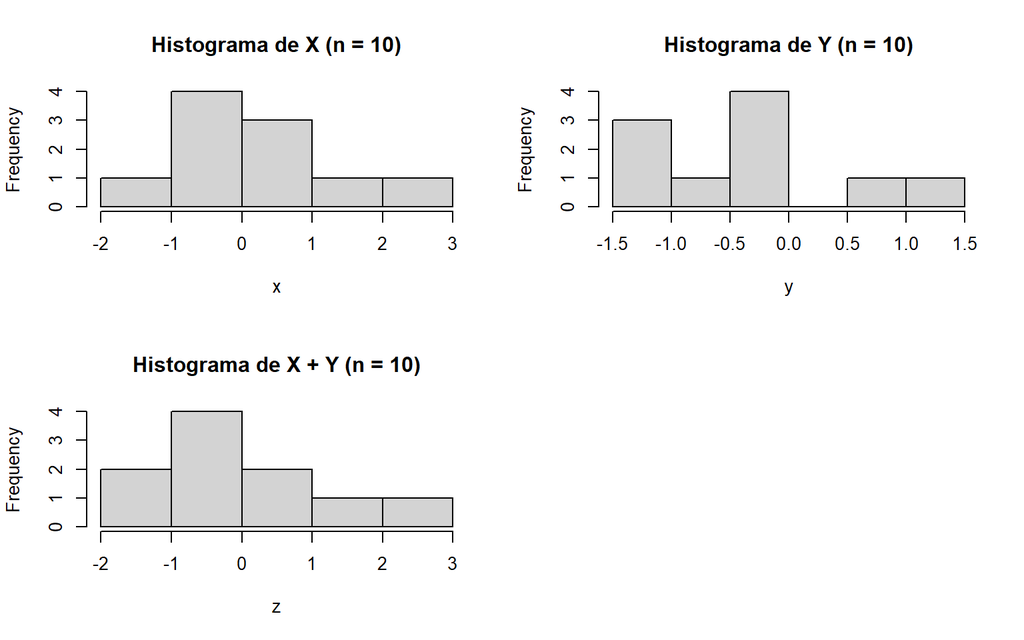

```r
#Grafica para n=10
par(mfrow = c(2,2))
hist(x, main = "Histograma de X (n = 10)")
hist(y, main = "Histograma de Y (n = 10)")
hist(z, main = "Histograma de X + Y (n = 10)")
```

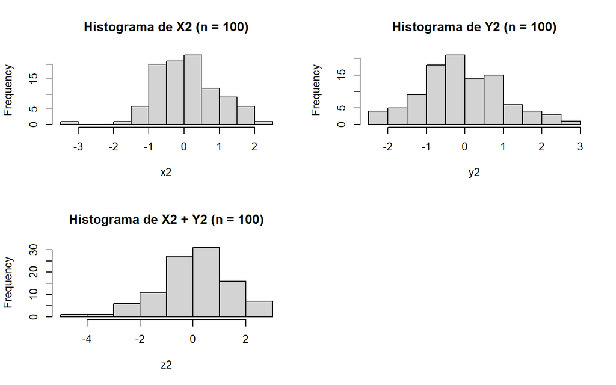

```r
#Grafica para n=100
par(mfrow = c(2,2))
hist(x2, main = "Histograma de X2 (n = 100)")
hist(y2, main = "Histograma de Y2 (n = 100)")
hist(z2, main = "Histograma de X2 + Y2 (n = 100)")
```

¿Qué observa si grafica ambos objetos? R/ Se observa en las gráficas anteriores que las variables normales graficadas individualmente tienden a mostrar una curva normal, al sumarlas sigue esta misma tendencia. Al aumentar las muestras se observa que el parecido a una curva normal perfecta se va observando más definida, si se aumentara el valor de n se vería este aspecto. A continuación, se presenta la simulación con n=10000:

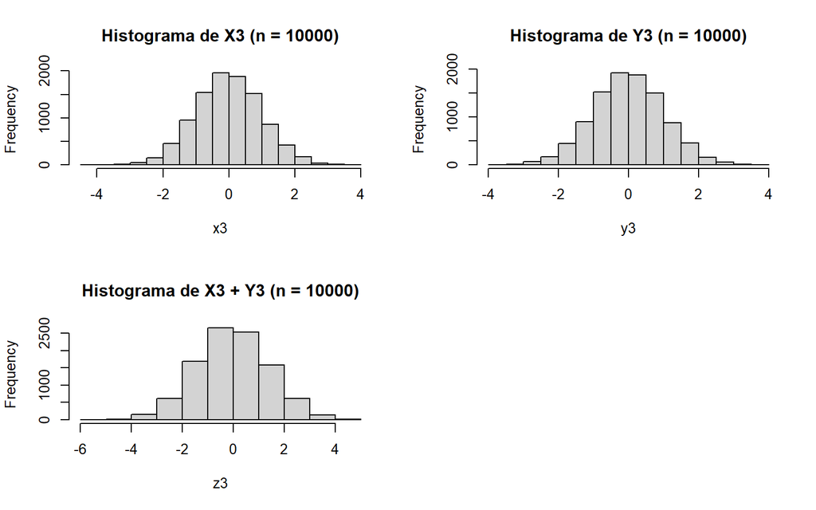

```r
#n=10000
n3 <- 10000
x3 <- rnorm(n3, mean = 0, sd = 1)
y3 <- rnorm(n3, mean = 0, sd = 1)
z3 <- x3 + y3

#Grafica para n=10000
par(mfrow = c(2,2))
hist(x3, main = "Histograma de X3 (n = 10000)")
hist(y3, main = "Histograma de Y3 (n = 10000)")
hist(z3, main = "Histograma de X3 + Y3 (n = 10000)")
```

2. Simular la suma de dos variables normales mediante la función rnorm(x,mu,sigma) en R con media igual a 0 y desvío igual a 1. Probar con distintos valores de tamaño de muestra. Podría probar con n = 100, n = 1000, n = 10000, n = 100000. Gráficar para estos distintos valores de muestra. Comprobar que la media (valor esperado) es igual a la suma de sus valores esperados y la varianza es igual a la suma de varianzas individuales.